# Домашнее задание к занятию 2.1: Деревья решений. Классификация

## Обзор прошедшего занятия

Что мы делали в классе:

**Задание 1**

- строили деревья
- критерии информативности которых написали даже сами
- визуализировали границы принятия решений в 2d
- и рисовали сами деревья

**Задание 2**

- приняли участие в соревновании на Kaggle, переварив кучу текстовых фичей в численные, проведя кросс-валидацию и сделав сабмит

**Задание 3**

- построили руками несколько метрик качества бинарной классификации

**Задание 4**

- использовали их для оценки классификации разделения статей Ведомостей по топикам

*дополнительно было много приятных ништяков. Например, облако слов, мультипоточность в целях парсинга, удобный инструмент для нахождения правильной css разметки, сохранение моделей в статичные файлы, разделение строк на слова и лемматизация этих слов*

## Домашнее задание

**Lvl 1:**

- взять подготовленные раннее данные из задачи **Titanic**, обучиться на них с помощью дерева решений и кросс-валидации и сделать сабмит
- кросс-валидацию желательно сделать сразу по нескольким фичам ( параметр *grid* в *GridSearchCV* )
- определить самые важные фичи
- вывести дерево решений (можете попробовать установить pydot и webgraphviz для отрисовки деревьев внутри ноутбука)

```python
import numpy as np
import pandas as pd
import matplotlib.pyplot as plt
import seaborn as sns
import sklearn
from sklearn.tree import DecisionTreeClassifier
```

```python
train_ds = pd.read_csv('../titanic/train.csv')
test_ds = pd.read_csv('../titanic/test.csv')
```

```python
train_ds.shape, test_ds.shape
```

```
((891, 12), (418, 11))
```

Работа с данными

```python
train_ds.columns
```

```
Index(['PassengerId', 'Survived', 'Pclass', 'Name', 'Sex', 'Age', 'SibSp',
       'Parch', 'Ticket', 'Fare', 'Cabin', 'Embarked'],
      dtype='object')
```

```python
from sklearn.preprocessing import LabelEncoder
```

```python
def add_features(ds, is_train=False, cabin_encoder=None, embarked_encoder=None, age_mode=None, fare_mode=None):
    ds['Sex_male'] = ds['Sex']=='male'
    ds['Cabin_letter'] = [x[0] if x is not np.nan else '-' for x in ds['Cabin']]
    if is_train:
        cabin_encoder = LabelEncoder()
        cabin_encoder.fit(ds['Cabin_letter'])
    else:
        pass
    ds['Cabin_letter_enc'] = cabin_encoder.transform(ds['Cabin_letter'])
    ds['Embarked'] = ds['Embarked'].fillna('-')
    if is_train:
        embarked_encoder = LabelEncoder()
        embarked_encoder.fit(ds['Embarked'])
    else:
        pass
    ds['Embarked_enc'] = embarked_encoder.transform(ds['Embarked'])
    age_mode = ds['Age'].mode()[0] if age_mode is None else age_mode
    ds['Age'] = ds['Age'].fillna(age_mode)
    fare_mode = ds['Fare'].mode()[0] if fare_mode is None else fare_mode
    ds['Fare'] = ds['Fare'].fillna(fare_mode)
    return ds, cabin_encoder, embarked_encoder, age_mode, fare_mode
```

```python
train_ds.loc[train_ds['Embarked']=='0', 'Embarked'] = None
```

```python
ds, cabin_encoder, embarked_encoder, age_mode, fare_mode = add_features(train_ds, is_train=True)
add_features(test_ds, cabin_encoder=cabin_encoder, embarked_encoder=embarked_encoder, age_mode=age_mode, fare_mode=fare_mode);
```

Базовая модель

```python
tree = DecisionTreeClassifier()
feats = ['Pclass', 'Sex_male','Age','SibSp','Parch','Fare','Cabin_letter_enc','Embarked_enc']
tree.fit(train_ds[feats], train_ds['Survived'])
```

```
DecisionTreeClassifier(class_weight=None, criterion='gini', max_depth=None,
            max_features=None, max_leaf_nodes=None,
            min_impurity_decrease=0.0, min_impurity_split=None,
            min_samples_leaf=1, min_samples_split=2,
            min_weight_fraction_leaf=0.0, presort=False, random_state=None,
            splitter='best')
```

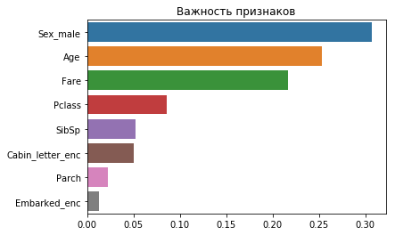

```python
feat_imps = pd.Series(tree.feature_importances_, index=feats).sort_values(ascending=False)
sns.barplot(x=feat_imps.values, y=feat_imps.index)
plt.title('Важность признаков')
plt.show()
```

Grid search

```python
from sklearn.model_selection import GridSearchCV
```

```python
grid = {
    'criterion':['gini','entropy'],
    'max_depth':[2,5,10,15,20,25,30,50,100,500,100],
    'min_samples_split': [2,5,10,50],
    'random_state':[42],
}
```

```python
gs = GridSearchCV(DecisionTreeClassifier(), grid, cv=10)
gs.fit(train_ds[feats], train_ds['Survived'])
```

```
GridSearchCV(cv=10, error_score='raise-deprecating',
       estimator=DecisionTreeClassifier(class_weight=None, criterion='gini', max_depth=None,
            max_features=None, max_leaf_nodes=None,
            min_impurity_decrease=0.0, min_impurity_split=None,
            min_samples_leaf=1, min_samples_split=2,
            min_weight_fraction_leaf=0.0, presort=False, random_state=None,
            splitter='best'),
       fit_params=None, iid='warn', n_jobs=None,
       param_grid={'criterion': ['gini', 'entropy'], 'max_depth': [2, 5, 10, 15, 20, 25, 30, 50, 100, 500, 100], 'min_samples_split': [2, 5, 10, 50], 'random_state': [42]},
       pre_dispatch='2*n_jobs', refit=True, return_train_score='warn',
       scoring=None, verbose=0)
```

```python
gs_res = pd.DataFrame(gs.cv_results_)
print(gs_res.shape)
gs_res.head()
```

```
(88, 34)
```

|  | mean_fit_time | std_fit_time | mean_score_time | std_score_time | param_criterion | param_max_depth | param_min_samples_split | param_random_state | params | split0_test_score | ... | split2_train_score | split3_train_score | split4_train_score | split5_train_score | split6_train_score | split7_train_score | split8_train_score | split9_train_score | mean_train_score | std_train_score |
| --- | --- | --- | --- | --- | --- | --- | --- | --- | --- | --- | --- | --- | --- | --- | --- | --- | --- | --- | --- | --- | --- |
| 0 | 0.003212 | 0.001629 | 0.000954 | 0.000329 | gini | 2 | 2 | 42 | {'criterion': 'gini', 'max_depth': 2, 'min_sam... | 0.700000 | ... | 0.790524 | 0.780549 | 0.785536 | 0.788030 | 0.789277 | 0.798005 | 0.784289 | 0.789539 | 0.790001 | 0.006129 |
| 1 | 0.002029 | 0.000011 | 0.000692 | 0.000006 | gini | 2 | 5 | 42 | {'criterion': 'gini', 'max_depth': 2, 'min_sam... | 0.700000 | ... | 0.790524 | 0.780549 | 0.785536 | 0.788030 | 0.789277 | 0.798005 | 0.784289 | 0.789539 | 0.790001 | 0.006129 |
| 2 | 0.002015 | 0.000012 | 0.000697 | 0.000007 | gini | 2 | 10 | 42 | {'criterion': 'gini', 'max_depth': 2, 'min_sam... | 0.700000 | ... | 0.790524 | 0.780549 | 0.785536 | 0.788030 | 0.789277 | 0.798005 | 0.784289 | 0.789539 | 0.790001 | 0.006129 |
| 3 | 0.002008 | 0.000009 | 0.000692 | 0.000007 | gini | 2 | 50 | 42 | {'criterion': 'gini', 'max_depth': 2, 'min_sam... | 0.700000 | ... | 0.790524 | 0.780549 | 0.785536 | 0.788030 | 0.789277 | 0.798005 | 0.784289 | 0.789539 | 0.790001 | 0.006129 |
| 4 | 0.002360 | 0.000019 | 0.000702 | 0.000005 | gini | 5 | 2 | 42 | {'criterion': 'gini', 'max_depth': 5, 'min_sam... | 0.744444 | ... | 0.860349 | 0.849127 | 0.842893 | 0.850374 | 0.852868 | 0.859102 | 0.847880 | 0.849315 | 0.852976 | 0.006126 |

5 rows × 34 columns

```python
for f in [x for x in gs_res.columns if x.startswith('param_')]:
    print(f, gs_res[f].value_counts())
    print()
```

```
param_criterion gini       44
entropy    44
Name: param_criterion, dtype: int64

param_max_depth 100    16
15      8
30      8
10      8
25      8
5       8
20      8
500     8
2       8
50      8
Name: param_max_depth, dtype: int64

param_min_samples_split 5     22
10    22
2     22
50    22
Name: param_min_samples_split, dtype: int64

param_random_state 42    88
Name: param_random_state, dtype: int64
```

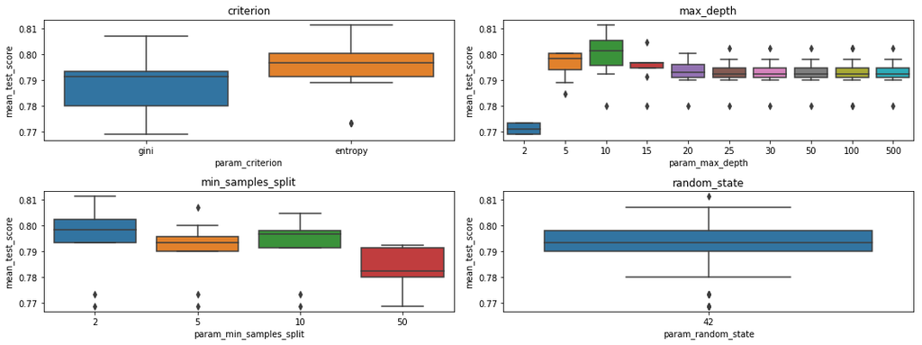

```python
plt.figure(figsize=(15,8))
for idx, p in enumerate(grid.keys()):
    plt.subplot(len(grid)//2+1,2,idx+1)
    plt.title(p)
    #cds = gs_res.groupby('param_'+p)['mean_train_score'].mean()
    sns.boxplot(x='param_'+p, y='mean_test_score',data=gs_res)
plt.tight_layout()
plt.show()
```

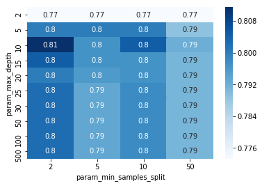

```python
cds = gs_res[gs_res['param_criterion']=='entropy'].pivot_table(index='param_max_depth',columns='param_min_samples_split', values='mean_test_score')
sns.heatmap(cds, cmap='Blues', annot=True)
```

```python
tree_gs = DecisionTreeClassifier(max_depth=10, min_samples_split=2,criterion='entropy',random_state=42)
tree_gs.fit(train_ds[feats], train_ds['Survived'])
```

```
DecisionTreeClassifier(class_weight=None, criterion='entropy', max_depth=10,
            max_features=None, max_leaf_nodes=None,
            min_impurity_decrease=0.0, min_impurity_split=None,
            min_samples_leaf=1, min_samples_split=2,
            min_weight_fraction_leaf=0.0, presort=False, random_state=42,
            splitter='best')
```

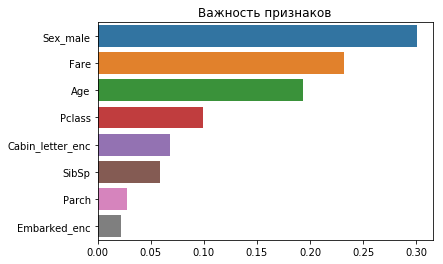

```python
feat_imps = pd.Series(tree_gs.feature_importances_, index=feats).sort_values(ascending=False)
sns.barplot(x=feat_imps.values, y=feat_imps.index)
plt.title('Важность признаков')
plt.show()
```

Только важные признаки

```python
imp_feats = ['Sex_male', 'Age','Fare']
```

```python
grid = {
    'criterion':['gini','entropy'],
    'max_depth':[2,5,10,15,20,25,30,50,100,500,100],
    'min_samples_split': [2,5,10,50],
    'random_state':[42],
}
```

```python
gs = GridSearchCV(DecisionTreeClassifier(), grid, cv=10)
gs.fit(train_ds[imp_feats], train_ds['Survived'])
```

```
GridSearchCV(cv=10, error_score='raise-deprecating',
       estimator=DecisionTreeClassifier(class_weight=None, criterion='gini', max_depth=None,
            max_features=None, max_leaf_nodes=None,
            min_impurity_decrease=0.0, min_impurity_split=None,
            min_samples_leaf=1, min_samples_split=2,
            min_weight_fraction_leaf=0.0, presort=False, random_state=None,
            splitter='best'),
       fit_params=None, iid='warn', n_jobs=None,
       param_grid={'criterion': ['gini', 'entropy'], 'max_depth': [2, 5, 10, 15, 20, 25, 30, 50, 100, 500, 100], 'min_samples_split': [2, 5, 10, 50], 'random_state': [42]},
       pre_dispatch='2*n_jobs', refit=True, return_train_score='warn',
       scoring=None, verbose=0)
```

```python
gs_res = pd.DataFrame(gs.cv_results_)
print(gs_res.shape)
gs_res.head()
```

```
(88, 34)
```

|  | mean_fit_time | std_fit_time | mean_score_time | std_score_time | param_criterion | param_max_depth | param_min_samples_split | param_random_state | params | split0_test_score | ... | split2_train_score | split3_train_score | split4_train_score | split5_train_score | split6_train_score | split7_train_score | split8_train_score | split9_train_score | mean_train_score | std_train_score |
| --- | --- | --- | --- | --- | --- | --- | --- | --- | --- | --- | --- | --- | --- | --- | --- | --- | --- | --- | --- | --- | --- |
| 0 | 0.002938 | 0.001144 | 0.001070 | 0.000434 | gini | 2 | 2 | 42 | {'criterion': 'gini', 'max_depth': 2, 'min_sam... | 0.766667 | ... | 0.795511 | 0.780549 | 0.795511 | 0.798005 | 0.799252 | 0.798005 | 0.789277 | 0.789539 | 0.792742 | 0.005737 |
| 1 | 0.001707 | 0.000060 | 0.000673 | 0.000011 | gini | 2 | 5 | 42 | {'criterion': 'gini', 'max_depth': 2, 'min_sam... | 0.766667 | ... | 0.795511 | 0.780549 | 0.795511 | 0.798005 | 0.799252 | 0.798005 | 0.789277 | 0.789539 | 0.792742 | 0.005737 |
| 2 | 0.001674 | 0.000006 | 0.000662 | 0.000004 | gini | 2 | 10 | 42 | {'criterion': 'gini', 'max_depth': 2, 'min_sam... | 0.766667 | ... | 0.795511 | 0.780549 | 0.795511 | 0.798005 | 0.799252 | 0.798005 | 0.789277 | 0.789539 | 0.792742 | 0.005737 |
| 3 | 0.001678 | 0.000009 | 0.000667 | 0.000017 | gini | 2 | 50 | 42 | {'criterion': 'gini', 'max_depth': 2, 'min_sam... | 0.766667 | ... | 0.795511 | 0.780549 | 0.795511 | 0.798005 | 0.799252 | 0.798005 | 0.789277 | 0.789539 | 0.792742 | 0.005737 |
| 4 | 0.001919 | 0.000017 | 0.000669 | 0.000005 | gini | 5 | 2 | 42 | {'criterion': 'gini', 'max_depth': 5, 'min_sam... | 0.766667 | ... | 0.826683 | 0.817955 | 0.822943 | 0.830424 | 0.821696 | 0.850374 | 0.816708 | 0.825654 | 0.828410 | 0.009639 |

5 rows × 34 columns

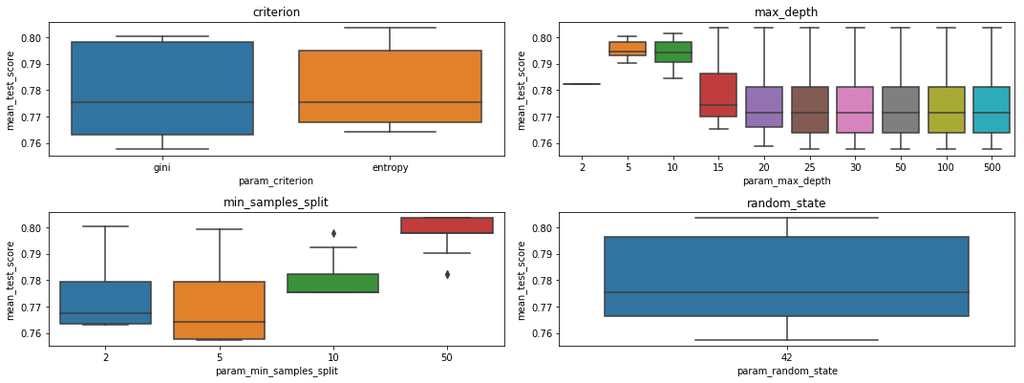

```python
plt.figure(figsize=(15,8))
for idx, p in enumerate(grid.keys()):
    plt.subplot(len(grid)//2+1,2,idx+1)
    plt.title(p)
    #cds = gs_res.groupby('param_'+p)['mean_train_score'].mean()
    sns.boxplot(x='param_'+p, y='mean_test_score',data=gs_res)
plt.tight_layout()
plt.show()
```

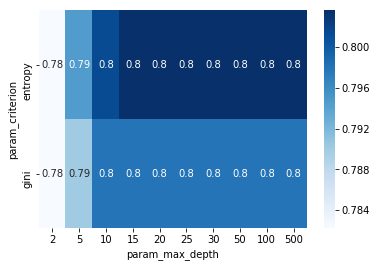

```python
cds = gs_res[gs_res['param_min_samples_split']==50].pivot_table(index='param_criterion',columns='param_max_depth', values='mean_test_score')
sns.heatmap(cds, cmap='Blues', annot=True)
```

```python
tree_gs_short = DecisionTreeClassifier(max_depth=15, min_samples_split=50,criterion='entropy',random_state=42)
tree_gs_short.fit(train_ds[imp_feats], train_ds['Survived'])
```

```
DecisionTreeClassifier(class_weight=None, criterion='entropy', max_depth=15,
            max_features=None, max_leaf_nodes=None,
            min_impurity_decrease=0.0, min_impurity_split=None,
            min_samples_leaf=1, min_samples_split=50,
            min_weight_fraction_leaf=0.0, presort=False, random_state=42,
            splitter='best')
```

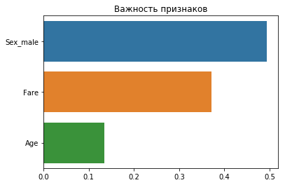

```python
feat_imps = pd.Series(tree_gs_short.feature_importances_, index=imp_feats).sort_values(ascending=False)
sns.barplot(x=feat_imps.values, y=feat_imps.index)
plt.title('Важность признаков')
plt.show()
```

Визуализация дерева

```python
import pydotplus
from sklearn.tree import export_graphviz
from IPython.display import Image
import re
```

Полное дерево

```python
dot_data = export_graphviz(tree_gs, feature_names=feats, out_file=None, class_names=['dead','survived'])

dot_data = re.sub(r'entropy = 0\.\d+', '', dot_data)
dot_data = re.sub(r'value = \[(\d|,| )+\]', '', dot_data)
dot_data = re.sub(r'\\n"', '"', dot_data)
dot_data = re.sub(r'(\\n)+', r'\\n', dot_data)

graph = pydotplus.graph_from_dot_data(dot_data)
```

[figure not shown]

```python
Image(graph.create_png())
```

Только важные признаки

```python
dot_data = export_graphviz(tree_gs_short, feature_names=imp_feats, out_file=None, class_names=['dead','survived'])

dot_data = re.sub(r'entropy = 0\.\d+', '', dot_data)
dot_data = re.sub(r'value = \[(\d|,| )+\]', '', dot_data)
dot_data = re.sub(r'\\n"', '"', dot_data)
dot_data = re.sub(r'(\\n)+', r'\\n', dot_data)

graph = pydotplus.graph_from_dot_data(dot_data)
```

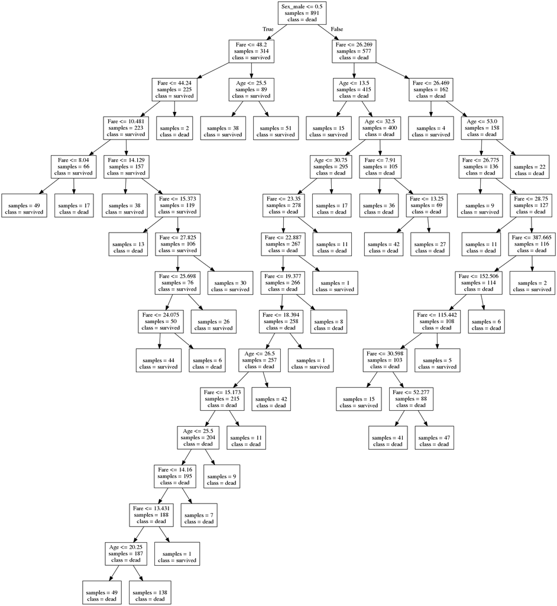

```python
Image(graph.create_png())
```

```python
tree_gs_short.fit(train_ds[imp_feats], train_ds['Survived'])
test_ds['Preds'] = tree_gs_short.predict(test_ds[imp_feats])
```

```python
to_kaggle = test_ds[['PassengerId','Preds']].rename(columns={'Preds':'Survived'})
to_kaggle.to_csv('submission.csv', index=False)
to_kaggle.head()
```

|  | PassengerId | Survived |
| --- | --- | --- |
| 0 | 892 | 0 |
| 1 | 893 | 1 |
| 2 | 894 | 0 |
| 3 | 895 | 0 |
| 4 | 896 | 1 |

```python
tree_gs.fit(train_ds[feats], train_ds['Survived'])
test_ds['Preds'] = tree_gs.predict(test_ds[feats])
```

```python
to_kaggle = test_ds[['PassengerId','Preds']].rename(columns={'Preds':'Survived'})
to_kaggle.to_csv('submission_gs.csv', index=False)
to_kaggle.head()
```

|  | PassengerId | Survived |
| --- | --- | --- |
| 0 | 892 | 0 |
| 1 | 893 | 0 |
| 2 | 894 | 0 |
| 3 | 895 | 0 |
| 4 | 896 | 1 |

```python
tree.fit(train_ds[feats], train_ds['Survived'])
test_ds['Preds'] = tree.predict(test_ds[feats])
```

```python
to_kaggle = test_ds[['PassengerId','Preds']].rename(columns={'Preds':'Survived'})
to_kaggle.to_csv('submission_base.csv', index=False)
to_kaggle.head()
```

|  | PassengerId | Survived |
| --- | --- | --- |
| 0 | 892 | 0 |
| 1 | 893 | 0 |
| 2 | 894 | 1 |
| 3 | 895 | 1 |
| 4 | 896 | 1 |

**Lvl 2:** (опционально)

- С помощью функций sklearn.metrics.auc, precision, recall составить функцию для расчёта ROC-AUC, ROC-PRC
- Придумать себе интересную задачу на основе данных из интернета =) Спарсить ещё какой-нибудь сайт (не Ведомости) и решить задачу классификации. Делать свои проекты - круто. Если будут - кидайте мне =) [@NikitaKuznetsov](http://t.me/NikitaKuznesov)

```python
from sklearn.metrics import auc, precision_score, recall_score
```

```python
def get_ROC_PRC(probs, real):
    threshs = np.linspace(0.01,0.99,100)
    precs = [precision_score(real, probs>t) for t in threshs]
    recs = [recall_score(real, probs>t) for t in threshs]
    precs = [0]+precs+[1]
    recs = [1]+recs+[0]
    auc_prc = auc(recs, precs)
    return precs, recs, auc_prc
```

```python
n_train = int(len(train_ds)*0.8)
```

```python
tree.fit(train_ds[feats][:n_train], train_ds['Survived'][:n_train])
tree_gs.fit(train_ds[feats][:n_train], train_ds['Survived'][:n_train])
tree_gs_short.fit(train_ds[imp_feats][:n_train], train_ds['Survived'][:n_train]);
```

```python
train_ds['Pred'] = tree.predict_proba(train_ds[feats])[:,1]
precs, recs, auc_prc = get_ROC_PRC(train_ds['Pred'][n_train:], train_ds['Survived'][n_train:])
auc_prc
```

```
0.7611425650423213
```

```python
train_ds['Pred'] = tree_gs.predict_proba(train_ds[feats])[:,1]
precs_gs, recs_gs, auc_prc_gs = get_ROC_PRC(train_ds['Pred'][n_train:], train_ds['Survived'][n_train:])
auc_prc_gs
```

```
0.7670211388770913
```

```python
train_ds['Pred'] = tree_gs_short.predict_proba(train_ds[imp_feats])[:,1]
precs_gs_short, recs_gs_short, auc_prc_gs_short = get_ROC_PRC(train_ds['Pred'][n_train:], train_ds['Survived'][n_train:])
auc_prc_gs_short
```

```
0.7777891685515299
```

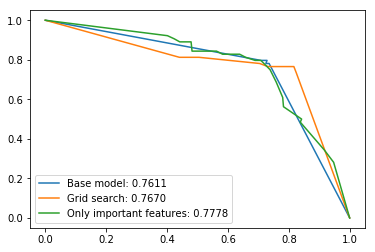

```python
plt.plot(precs, recs, label=f'Base model: {auc_prc:.4f}')
plt.plot(precs_gs, recs_gs, label=f'Grid search: {auc_prc_gs:.4f}')
plt.plot(precs_gs_short, recs_gs_short, label=f'Only important features: {auc_prc_gs_short:.4f}')
plt.legend()
plt.show()
```